# Natural Language Processing (NLP) prediction algorithm presentation

16 December 2017

## Introduction

The goal of this project was to build a predictive text model. By giving some input words, it should predict which is going to be the next word that the user will type. Important points for that purpose:

- **which data?** –> text data sets in English from three different media sources (blogs, news and tweets); some files with >800000 lines (aprox. 200 Mb per file)
- **which tools?** –> ‘’tm’’ turned to be not efficient with big size data so we used ‘’quanteda’’ package.
- **Model 1**: 50000 lines sample. **Model 2**: 100000 lines sample.
- **evaluate** models –> cross entropy, benchmarks
- build an **app** –> shiny

## Prediction Model: set up

Some needed transformations:

- conversion to *ASCII* format
- remove *contractions* (qdap package)
- remove url, numbers and special characters (~!@#$%^&*|(){}_+:"<>?,./;’[]-=)
- **profanity** filter (badwords removed)
- lower case and **stemming** used

> Building the models:
- **corpus** of the data sample
- *bigrams*, *trigrams* and *quatrigrams* used
- extract most frequent words (freq >1)
- **compare models** and select one

## Prediction algorithm

1. Last three input words –> search quatrigrams (highest frequencies)
2. If not found –> decrease nr. of input words (search trigrams and bigrams)
3. Several word combinations (simulating skip-grams) are incorporated.

**Evaluation**: 2 and 3 words uncomplete sentences selected to test the models.

**Model 1** : input sample size = 10 –> **selected**

```r
CrossEntropy = 19.1618
#Accuracy = 50%
AverageCrossEntropy = 3.83236
```

Model 2 : input sample size = 10

```r
CrossEntropy = 21.29822
#Accuracy = 50%
AverageCrossEntropy = 4.259644
```

**Benchmarking**: input sample size = 600 https://github.com/hfoffani/dsci-benchmark

```r
#with ''blogs'' dataset
Overall top-3 score:     13.43 %
Overall top-3 precision: 16.45 %
Average runtime:         129.13 msec
Number of predictions:   14483
Total memory used:       14.00 MB
```

Comparing with other results, we discovered a **exponential** relationship between accuracy and memory. For an algorithm to have a 2% accuracy increase, 250Mb more memory is needed.

## Shiny App

**Step 1** Provide an incomplete sentence. Ex: *if you know any* and click the “Predict” button. The “Clear” button helps to clear the text box and prediction table.

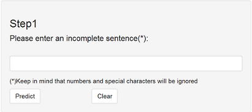

At the right side of the app, a table will appear showing the found matching-words in order of importance, the first word is the most probable one. Besides the elapsed time that the computer took to make the prediction (as a measure of performance) is given.

**Step 2** Now the user can help to improve the model by providing some feedback. Same as when typing with a smartphone. She or he must choose a word from the listed in the results table or provide a new correct one and click “Send feedback” button.

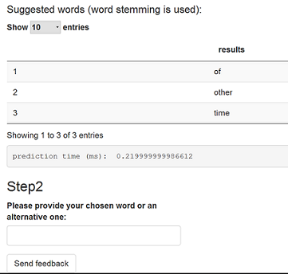

## Conclusions

1. *Exploratory data analysis* was performed on the text samples
2. A lot of *cleaning and preparation* of the data was needed
3. Building a **model** required many decisions:
   - sample *size*?
   - good *accuracy-performance* ratio?
   - *memory* restrictions
   - possible *improvements*?
4. A model was chosen and some *benchmarking* done
5. Focus was done on *top3* (3 input words) predictions
6. Find the *app* here: https://cyberosa.shinyapps.io/MakingPredictionsApp/
7. Source code available in github: https://github.com/cyberosa/datasciencecoursera/tree/master/NaturalLanguageProcessing